# SHapley Additive exPlanations (SHAP) analysis on Heart Attack dataset

## Task A

For the selected models, prepare a knitr/jupyter notebook based on the following points (you can use models created in Homework 1). Submit your results on GitHub to the directory `Homeworks/HW2`.

The notebook that this notebook bases on can be found at `Homeworks/HW1/PawelPawlik/main.ipynb`.

### 4. Find any two observations in the dataset, such that they have different variables of the highest importance, e.g. age and gender have the highest (absolute) attribution for observation A, but race and class are more important for observation B.

```
Chosen observations: (0, 7)
2 highest attributions (shap): (['cp_0', 'caa'], ['thall', 'oldpeak'])

 waterfall plot for first observation
```

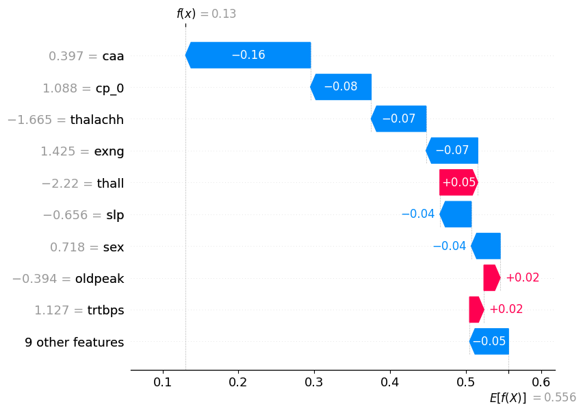

```
 waterfall plot for second observation
```

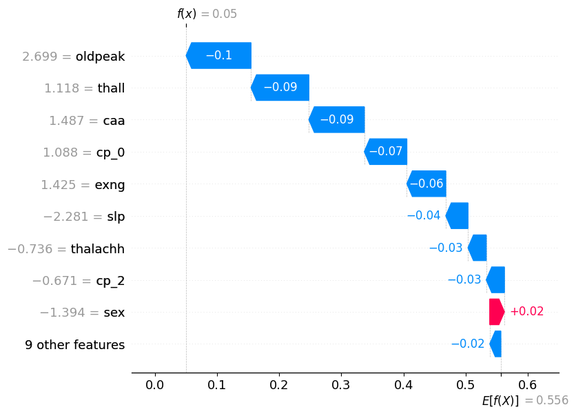

```
2 highest attributions (dalex): ['caa', 'cp_0'] ['caa', 'thall']
```

```python
task_A_4(True)
```

### 5. (If possible) Select one variable X and find two observations in the dataset such that for one observation, X has a positive attribution, and for the other observation, X has a negative attribution.

```python
task_A_56(True)
```

[output not shown]

We can see that there indeed exists a variable that has positive contribution in some observation and negative in other. This is not surprising as deepening on value and context variable may have opposite influence on the final score.

### 6. (How) Do the results differ across the two packages selected in point (3)?

#### 4.

We can see that dalex top 2 contribution variables accross selected two observations are similiar (there is only 1 difference caa vs oldpeak in second observetion). This shows that there may be significant difference in analysis across multiple packges (more on this in the comment to the point 7 below).

#### 5.

Results in point 5 are similar which could be expected but not certain (it would be not surprising to see opposite results as those packages need to approximate shap values, so the results could be more significantly different).

### 7. (Using one explanation package of choice) Train another model of any class: neural network, linear model, decision tree etc. and find an observation for which SHAP attributions are different between this model and the one trained in point (1).

```
most_diff_obs=55

 waterfall plot for RandomForest
```

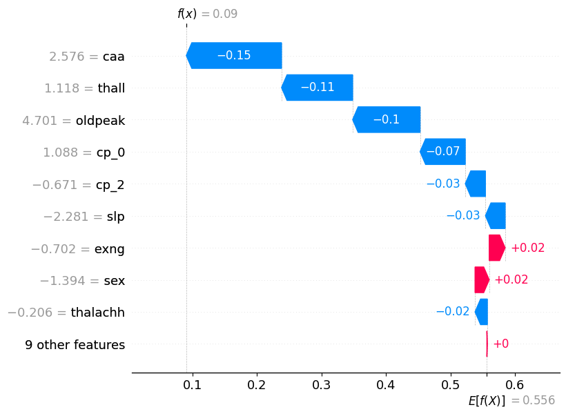

```
 waterfall plot for LogisticRegression
```

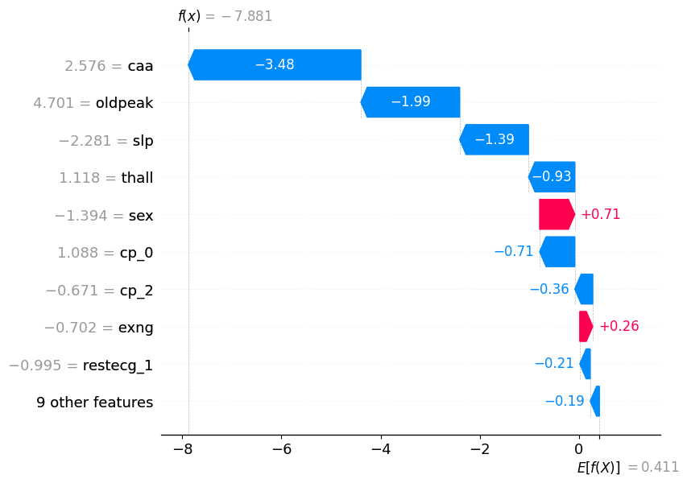

```python
task_A_7()
```

We can see that different models may have different shap attribution. Moreover, the most significant variables may be different (in the above example top 2 variables are caa nad thall in one observation, and caa and oldpeak in the other). This shows that we need to be careful when analyzing shap analysis results as the analysis does not present objective facts about dataset but the interpretations are significantly influenced by the model that was used. This is expected as at the end of the day we analyze the model.

## Task B

Calculate Shapley values for player A given the following value function. The method used for this calculations can be found on [slides](https://htmlpreview.github.io/?https://raw.githubusercontent.com/mim-uw/eXplainableMachineLearning-2023/main/Lectures/02_shap.html#/motivational-example-33-solution).

$ v() = 0 \\ v(A) = 20, \qquad \qquad \ A:+20 \\ v(B) = 20, \qquad \qquad \ B:+20 \\ v(C) = 60, \qquad \qquad \ C:+60 \\ v(A,B) = 60, \qquad \quad A:+40, B:+40 \\ v(A,C) = 70, \qquad \quad A:+10, C:+50 \\ v(B,C) = 70, \qquad \quad B:+10, C:+50 \\ v(A,B,C) = 100, \quad \ A:+30, B:+30, C:+40 $

$ \phi_A = \frac{1}{6}(20\cdot2 + 40 + 10 + 30\cdot2) = \frac{1}{6} 150 = 25 \\ \phi_B = \frac{1}{6}(20\cdot2 + 40 + 10 + 30\cdot2) = \frac{1}{6} 150 = 25 \\ \phi_C = \frac{1}{6}(60\cdot2 + 50 + 50 + 40\cdot2) = \frac{1}{6} 300 = 50 $

## Appendix

Source code

```python
import pandas as pd
from sklearn.model_selection import train_test_split
from sklearn.ensemble import GradientBoostingClassifier, RandomForestClassifier
from sklearn.linear_model import LogisticRegression
from sklearn.preprocessing import StandardScaler
from sklearn.metrics import RocCurveDisplay, roc_curve
import seaborn as sns
from sklearn.metrics import roc_auc_score, accuracy_score
import matplotlib.pyplot as plt
import numpy as np
import shap
import dalex as dx

np.random.seed(42)
OUTPUT_COLUMN = "output"
```

### A.1. Train a tree-based ensemble model on the selected dataset; it can be one of random forest, GBM, CatBoost, XGBoost, LightGBM (various types) etc.

I trained RandomForestClassifier in the first homework, so I will be using this model.

```python
def get_preprocessed_dataset():
    df = pd.read_csv("heart.csv")
    df = pd.get_dummies(df, columns=["cp", "restecg"])

    scaler = StandardScaler()

    X, y = df.drop(columns=[OUTPUT_COLUMN]), df[OUTPUT_COLUMN]
    X_train, X_test, y_train, y_test = train_test_split(
        X, y, test_size=0.33, random_state=42
    )

    X_train[:] = scaler.fit_transform(X_train)
    X_test[:] = scaler.transform(X_test)

    return X_train, X_test, y_train, y_test

X_train, X_test, y_train, y_test = get_preprocessed_dataset()
model = RandomForestClassifier().fit(X_train, y_train)
```

### A.2. Select two observations from the dataset and calculate the model's prediction.

```python
np.random.seed(123)
idxs = np.random.choice(len(X_test), 2)

X, y = X_test.iloc[idxs], y_test.iloc[idxs]
y_hat = model.predict_proba(X)[:, 1]
y_hat
```

```
array([0.27, 0.95])
```

### A.3. Next, for the same observations, calculate the decomposition of predictions, so-called variable attributions, using SHAP from two packages of choice, e.g. for Python: dalex and shap, for R: DALEX and iml.

I will use dalex and shap packages.

#### Shap

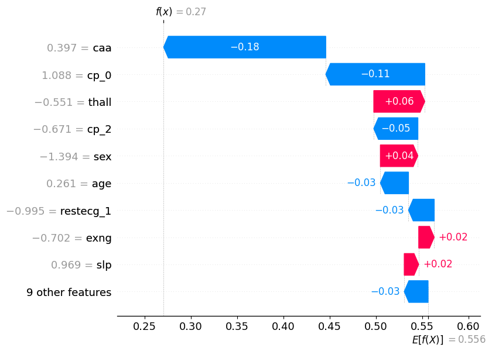

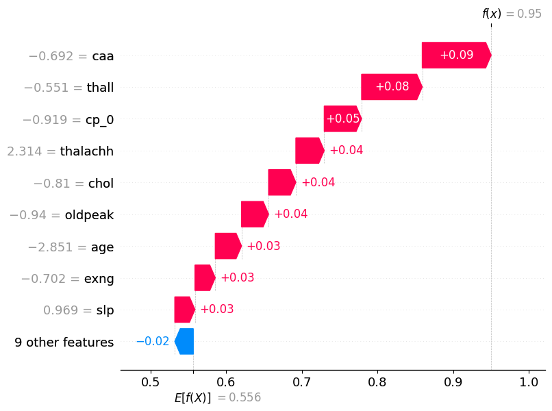

```python
shap_explainer = shap.Explainer(model, X_train)
shap_values = shap_explainer(X, check_additivity=False)

for v in shap_values:
    shap.plots.waterfall(v[:, 1])
```

#### Dalex

```python
dx_explainer = dx.Explainer(model, X_train, y_train, verbose=False)
for _, row in X.iterrows():
    dx_explainer.predict_parts(row).plot()
```

```
X does not have valid feature names, but RandomForestClassifier was fitted with feature names
```

### A.4. Find any two observations in the dataset, such that they have different variables of the highest importance, e.g. age and gender have the highest (absolute) attribution for observation A, but race and class are more important for observation B.

```
Chosen observations: (0, 7)
2 highest attributions (shap): (['cp_0', 'caa'], ['thall', 'oldpeak'])

 waterfall plot for first observation
```

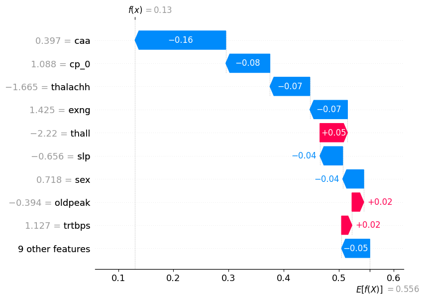

```
 waterfall plot for second observation
```

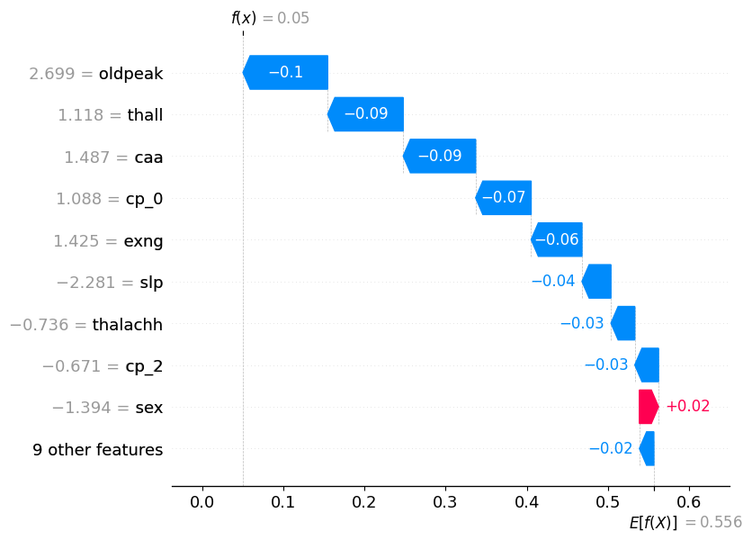

```
2 highest attributions (dalex): ['caa', 'cp_0'] ['caa', 'thall']
```

```python
def task_A_4(run_dalex=False):
    shap_values = shap_explainer(X_test, check_additivity=False)
    idx_obs_1 = 0
    shap_obs_1 = shap_values[idx_obs_1, : , 1]
    high_obs_1 = np.argsort(np.abs(shap_obs_1.values))[-2:]
    for i, v in enumerate(shap_values):
        idx_obs_2 = i
        shap_obs_2 = shap_values[idx_obs_2, : , 1]
        high_obs_2 = np.argsort(np.abs(shap_obs_2.values))[-2:]

        if (high_obs_1 == high_obs_2).any() or (high_obs_1 == high_obs_2[::-1]).any():
            continue
        break
    else: # no break
        raise Exception("matching observation not found")

    print(f"Chosen observations: {idx_obs_1,idx_obs_2}")
    print(f"2 highest attributions (shap): {X.columns[high_obs_1].tolist(),X.columns[high_obs_2].tolist()}")

    print("\n waterfall plot for first observation")
    shap.plots.waterfall(shap_obs_1)
    print("\n waterfall plot for second observation")
    shap.plots.waterfall(shap_obs_2)

    if not run_dalex:
        return

    dx_obs_1 = dx_explainer.predict_parts(X_test.iloc[idx_obs_1]).result.iloc[1:-1] # [1:-1] drop intercept and prediction
    dx_obs_2 = dx_explainer.predict_parts(X_test.iloc[idx_obs_2]).result.iloc[1:-1]
    dx_obs_1["contribution"] = dx_obs_1["contribution"].abs()
    dx_obs_2["contribution"] = dx_obs_2["contribution"].abs()
    dx_obs_1 = dx_obs_1.sort_values("contribution", ascending=False)
    dx_obs_2 = dx_obs_2.sort_values("contribution", ascending=False)

    print("2 highest attributions (dalex):", dx_obs_1["variable_name"][:2].tolist(), dx_obs_2["variable_name"][:2].tolist())
    dx_explainer.predict_parts(X_test.iloc[idx_obs_1]).plot()
    dx_explainer.predict_parts(X_test.iloc[idx_obs_2]).plot()


task_A_4(True)
```

### A.5 (If possible) Select one variable X and find two observations in the dataset such that for one observation, X has a positive attribution, and for the other observation, X has a negative attribution.

```python
def task_A_56(run_dalex=False):
    shap_values = shap_explainer(X_test, check_additivity=False)
    var = 0
    idx_obs_1 = 0
    shap_obs_1 = shap_values[idx_obs_1, : , 1]
    var_obs_1 = shap_obs_1.values[var]
    for i, v in enumerate(shap_values):
        idx_obs_2 = i
        shap_obs_2 = shap_values[idx_obs_2, : , 1]
        var_obs_2 = shap_obs_2.values[var]

        if var_obs_1 * var_obs_2 >= 0:
            continue
        break
    else: # no break
        raise Exception("matching observation not found")

    print(f"Chosen variable X: {X.columns[var]}")
    print(f"Chosen observations: {idx_obs_1,idx_obs_2}")
    print(f"Shap contributions for chosen observations: {var_obs_1,var_obs_2}")

    if not run_dalex:
        return

    dx_contr_obs_1 = dx_explainer.predict_parts(X_test.iloc[idx_obs_1]).result.set_index("variable_name").loc[X.columns[var]]["contribution"]
    dx_contr_obs_2 = dx_explainer.predict_parts(X_test.iloc[idx_obs_2]).result.set_index("variable_name").loc[X.columns[var]]["contribution"]
    print(f"Dalex contributions for chosen observations: {dx_contr_obs_1,dx_contr_obs_2}")

task_A_56(True)
```

```
Chosen variable X: age
Chosen observations: (0, 4)
Shap contributions for chosen observations: (-0.01128289675780252, 0.03937408661517111)
Dalex contributions for chosen observations: (-0.01517241379310344, 0.048866995073891806)
```

### A.7 (Using one explanation package of choice) Train another model of any class: neural network, linear model, decision tree etc. and find an observation for which SHAP attributions are different between this model and the one trained in point (1).

```
most_diff_obs=55

 waterfall plot for RandomForest
```

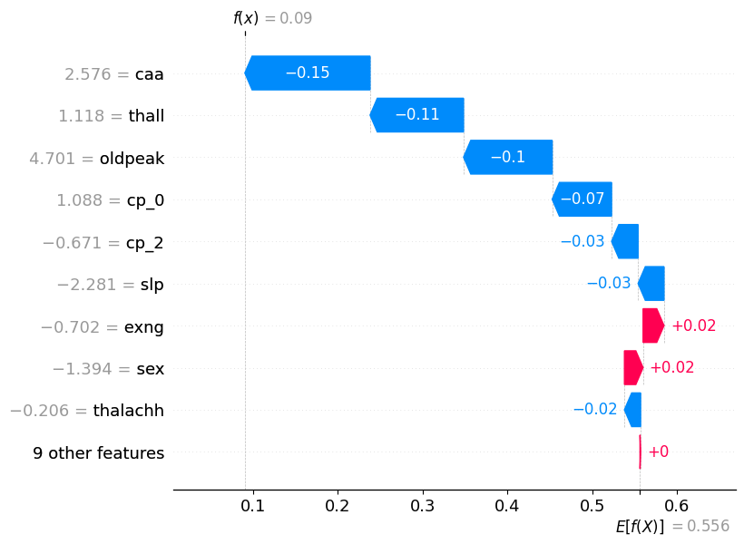

```
 waterfall plot for LogisticRegression
```

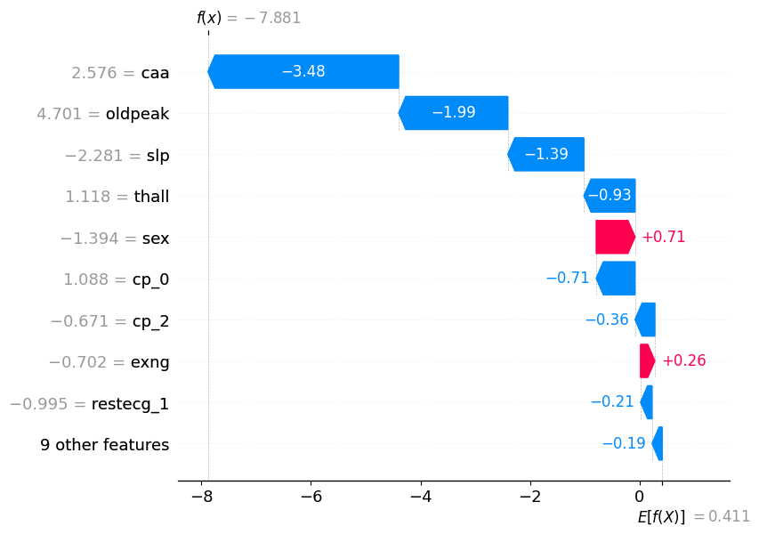

```python
def task_A_7():
    shap_values = shap_explainer(X_test, check_additivity=False)
    model2 = LogisticRegression().fit(X_train, y_train)
    shap_values2 = shap.Explainer(model2, X_train)(X_test)

    diff_shap_values = np.abs(shap_values[:, :, 1].values - shap_values2.values)

    most_diff_obs = np.argmax(diff_shap_values.sum(-1))
    print(f"{most_diff_obs=}")

    print("\n waterfall plot for RandomForest")
    shap.plots.waterfall(shap_values[most_diff_obs, :, 1])
    print("\n waterfall plot for LogisticRegression")
    shap.plots.waterfall(shap_values2[most_diff_obs])

task_A_7()
```